# Projeto2

Pedro Portela

25 de abril de 2018

## Projeto 2 - Regressão Linear

O presente projeto está organizado de forma sequencial, onde os diferentes modelos desenvolvidos estão organizados de acordo com o tipo de regressão e separados em abas por diferentes variáveis.

### Visualização inicial

Visualização inicial dos dados - Cinco primeiros registros

```
##   area garagem quartos preco
## 1 1.33       1       3   225
## 2 1.70       1       2   210
## 3 1.80       1       4   250
## 4 2.15       2       4   274
## 5 2.25       2       3   240
```

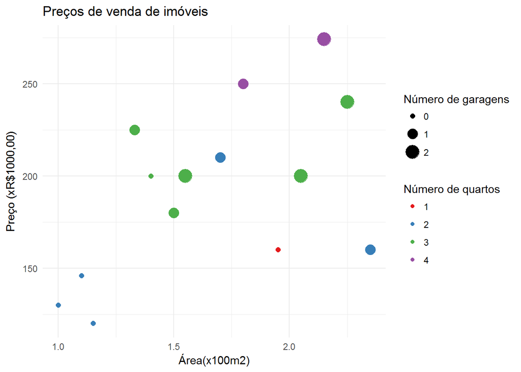

Visualmente, identifica-se uma correlação entre preço e os valores de área, número de quartos e garagens.

### Modelos de regressão

#### Correlações individuais

Visão geral

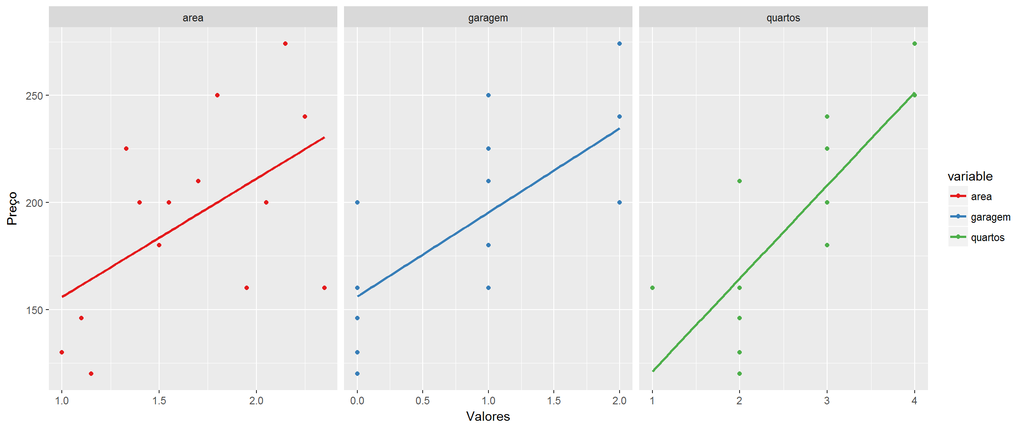

#### Análise dos modelos

A seguir, análise dos modelos propostos.

##### Preço ~ área

```r
areaLM <- lm(data = housingSmall, preco ~ area)
summary(areaLM)
```

```
##
## Call:
## lm(formula = preco ~ area, data = housingSmall)
##
## Residuals:
##     Min      1Q  Median      3Q     Max
## -70.447 -23.275   5.113  20.374  54.598
##
## Coefficients:
##             Estimate Std. Error t value Pr(>|t|)
## (Intercept)   100.67      43.45   2.317   0.0390 *
## area           55.22      25.31   2.182   0.0497 *
## ---
## Signif. codes:  0 '***' 0.001 '**' 0.01 '*' 0.05 '.' 0.1 ' ' 1
##
## Residual standard error: 40.38 on 12 degrees of freedom
## Multiple R-squared:  0.284,  Adjusted R-squared:  0.2243
## F-statistic:  4.76 on 1 and 12 DF,  p-value: 0.04974
```

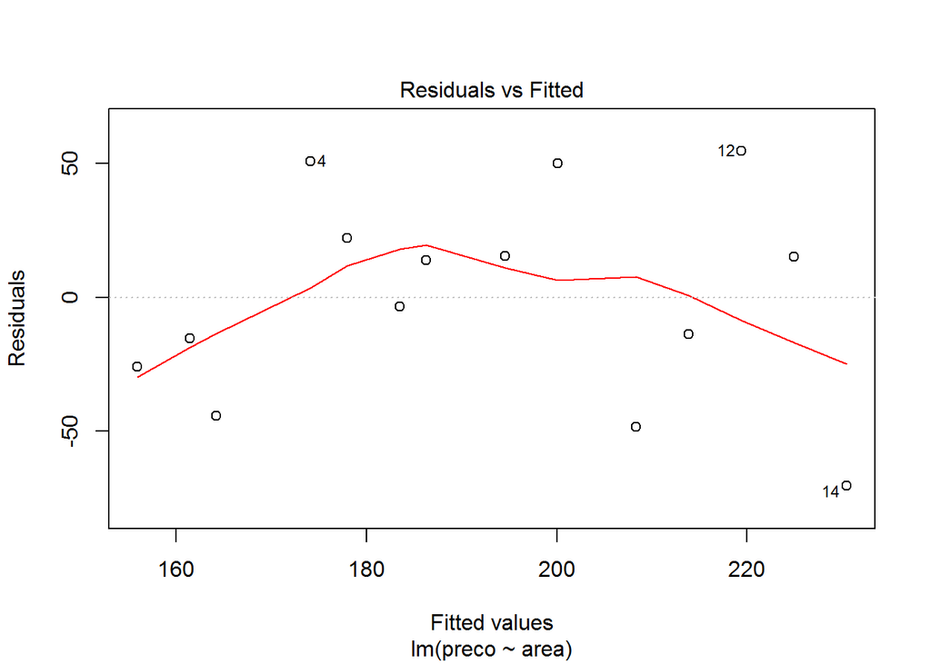

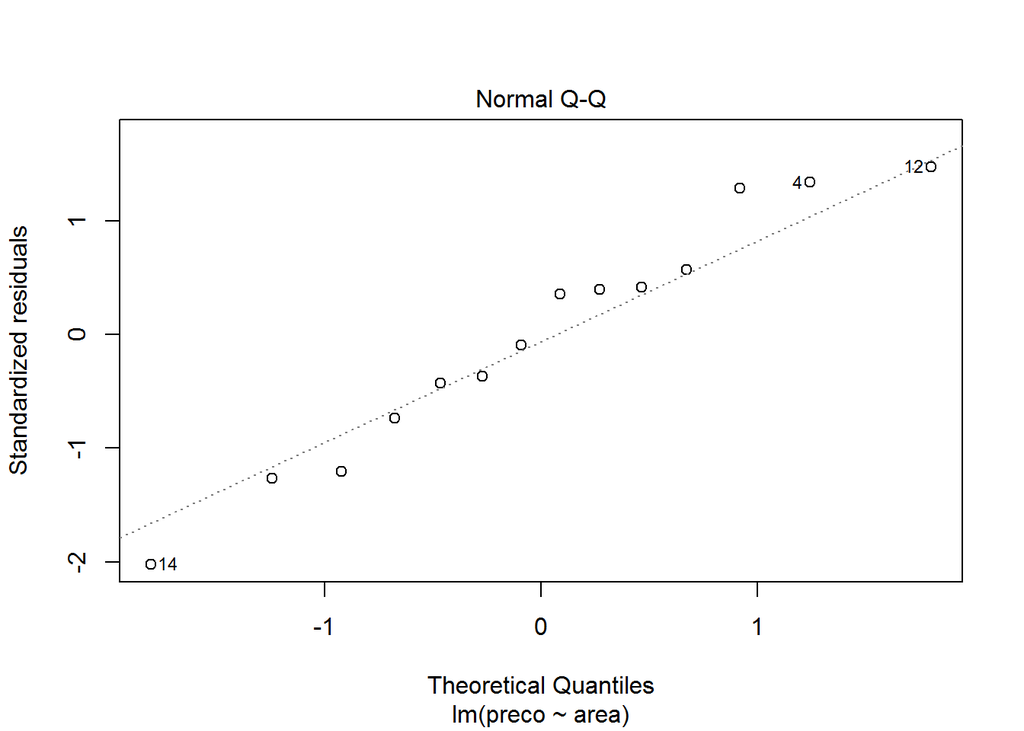

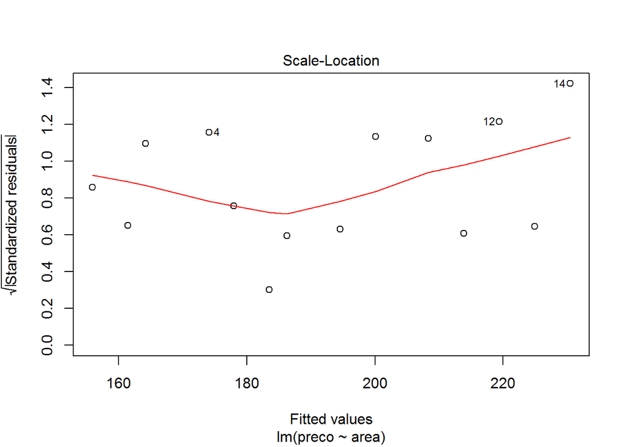

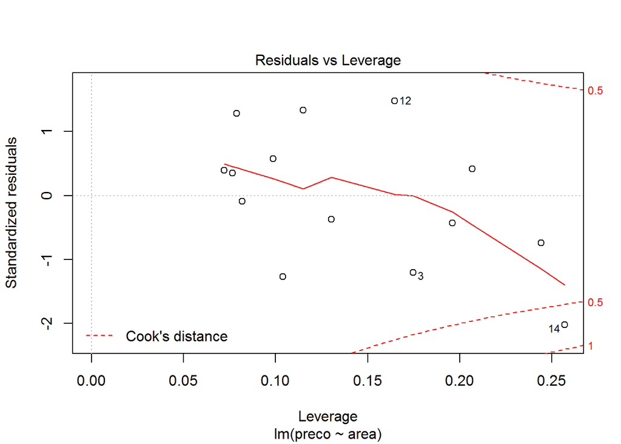

```r
plot(areaLM)
```

##### Preço ~ garagem

```r
garagemLM <- lm(data = housingSmall, preco ~ garagem)
summary(garagemLM)
```

```
##
## Call:
## lm(formula = preco ~ garagem, data = housingSmall)
##
## Residuals:
##     Min      1Q  Median      3Q     Max
## -36.048 -32.432  -3.048  25.946  54.696
##
## Coefficients:
##             Estimate Std. Error t value Pr(>|t|)
## (Intercept)   156.05      13.78  11.321 9.22e-08 ***
## garagem        39.26      11.25   3.488  0.00448 **
## ---
## Signif. codes:  0 '***' 0.001 '**' 0.01 '*' 0.05 '.' 0.1 ' ' 1
##
## Residual standard error: 33.63 on 12 degrees of freedom
## Multiple R-squared:  0.5035, Adjusted R-squared:  0.4621
## F-statistic: 12.17 on 1 and 12 DF,  p-value: 0.004479
```

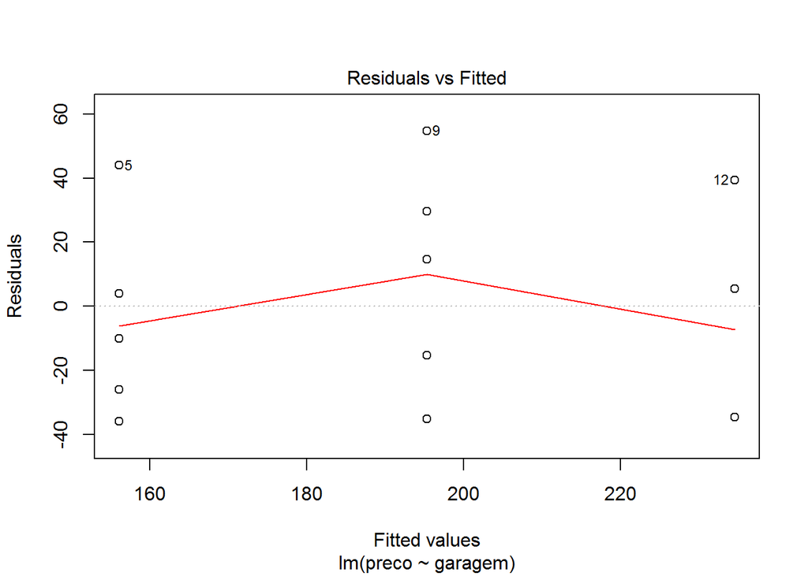

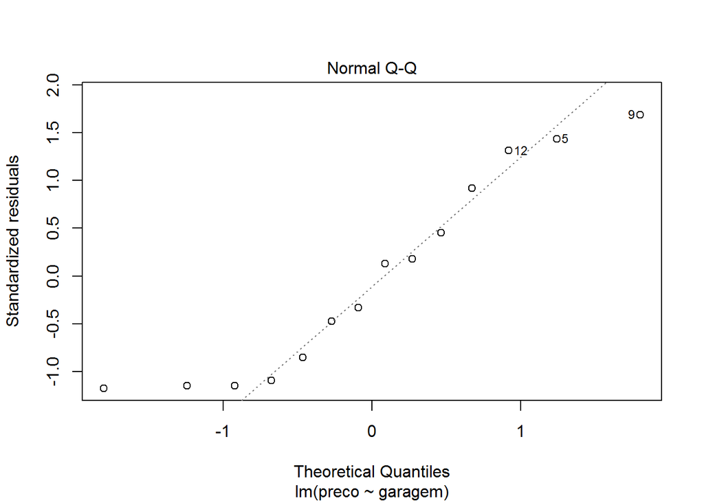

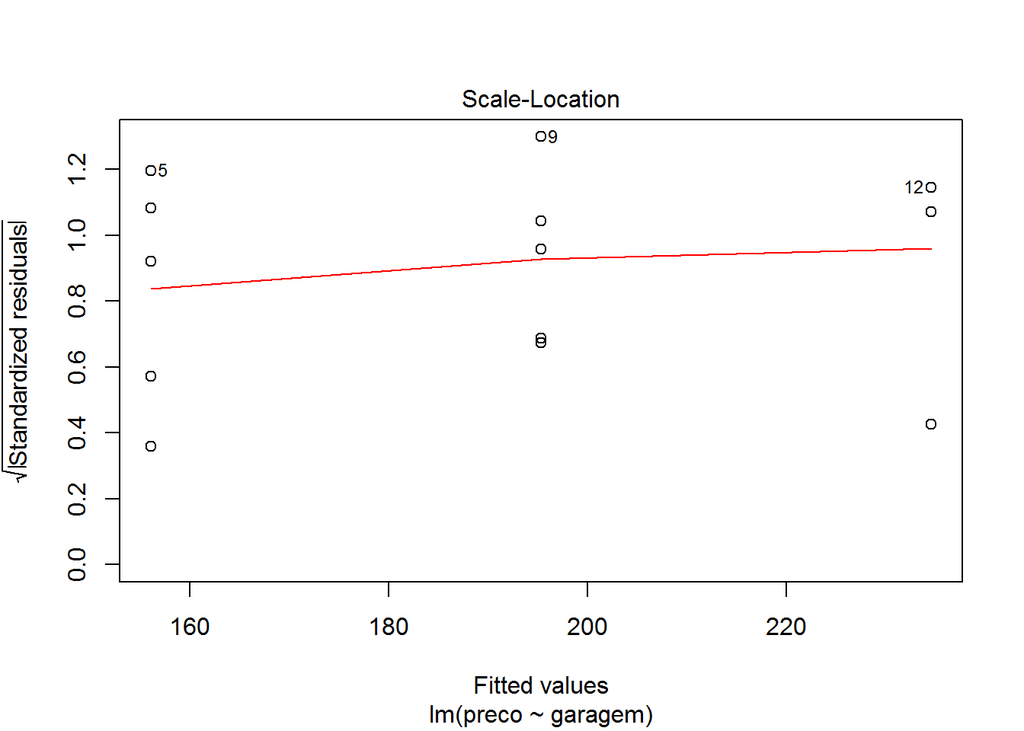

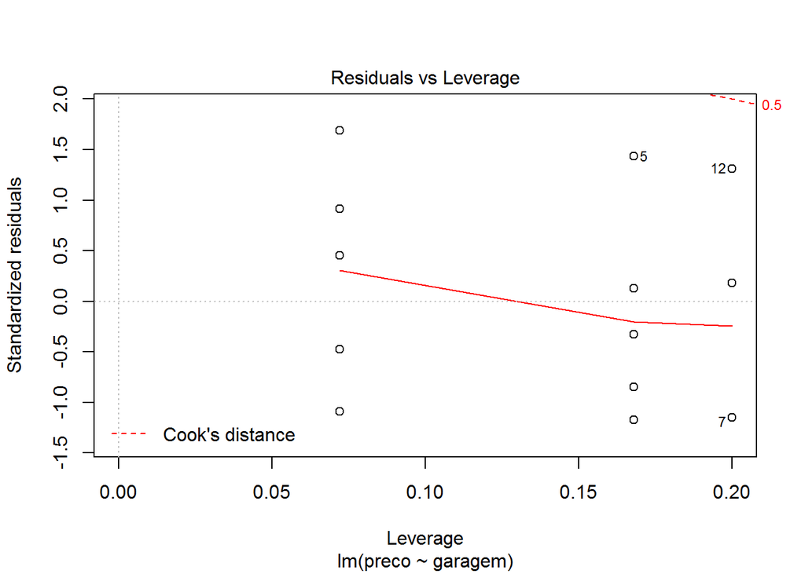

```r
plot(garagemLM)
```

##### Preço ~ quartos

```r
quartosLM <- lm(data = housingSmall, preco ~ quartos)
summary(quartosLM)
```

```
##
## Call:
## lm(formula = preco ~ quartos, data = housingSmall)
##
## Residuals:
##     Min      1Q  Median      3Q     Max
## -44.558 -15.924  -6.291  21.128  45.442
##
## Coefficients:
##             Estimate Std. Error t value Pr(>|t|)
## (Intercept)   77.628     26.188   2.964 0.011826 *
## quartos       43.465      9.473   4.588 0.000623 ***
## ---
## Signif. codes:  0 '***' 0.001 '**' 0.01 '*' 0.05 '.' 0.1 ' ' 1
##
## Residual standard error: 28.75 on 12 degrees of freedom
## Multiple R-squared:  0.637,  Adjusted R-squared:  0.6067
## F-statistic: 21.05 on 1 and 12 DF,  p-value: 0.0006232
```

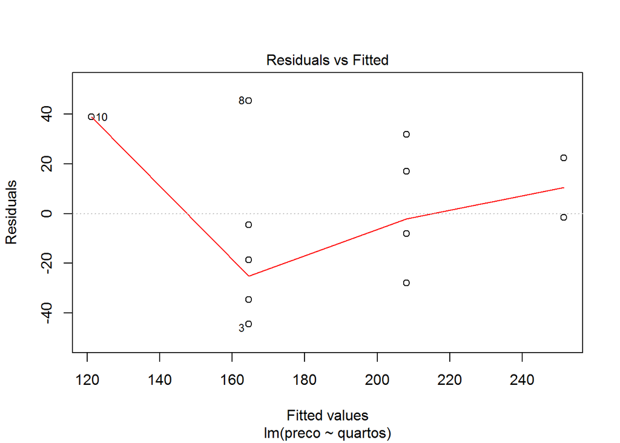

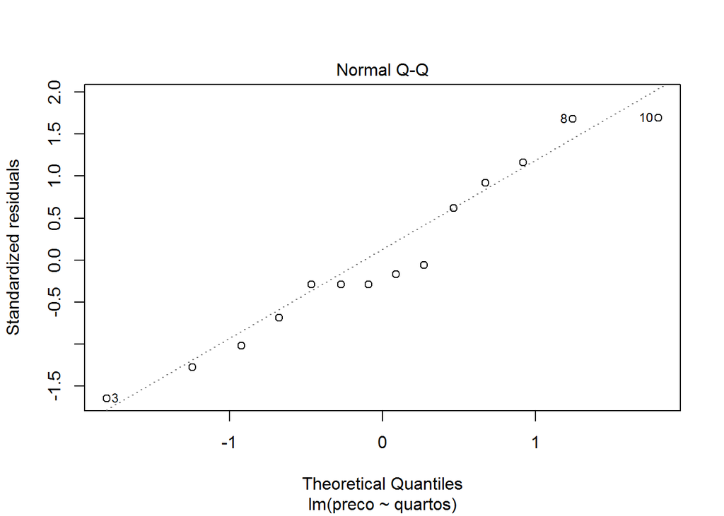

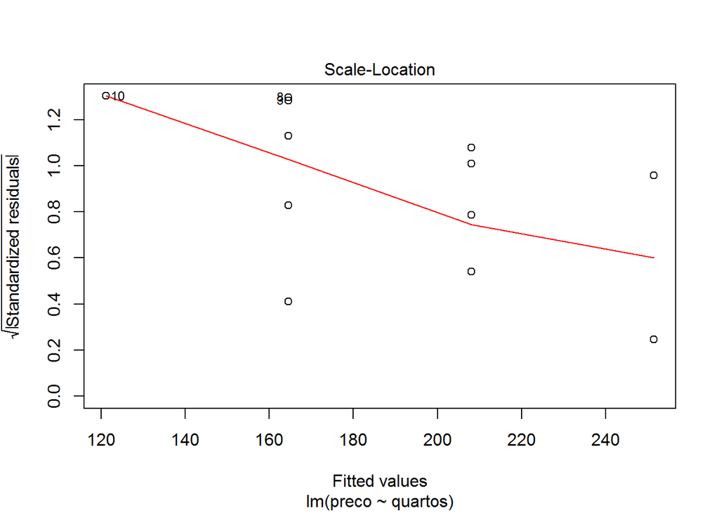

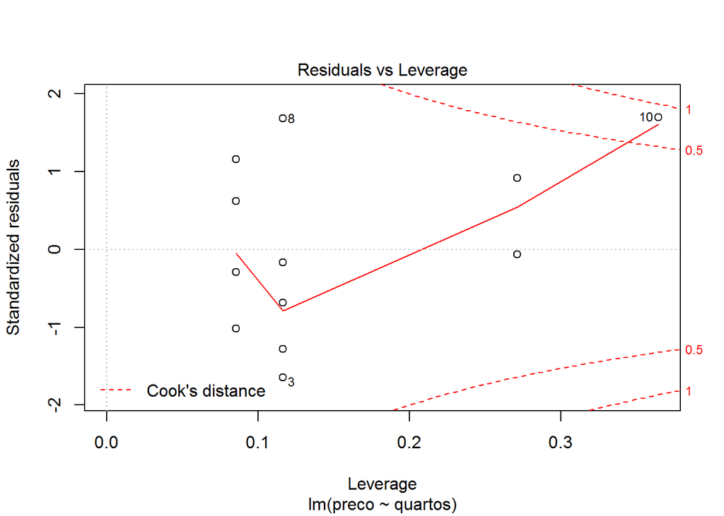

```r
plot(quartosLM)
```

Todos modelos apresentados acima tiveram baixos valores de R quadrado. A análise dos resíduos também expõe a oportunidade de melhoria do modelo.

Como os resíduos apresentaram comportamento não linear, propõe-se o desenvolvimento de um modelo de regressão polinomial quadrática.

#### Modelos de regressão quadrática

##### Preço ~ área

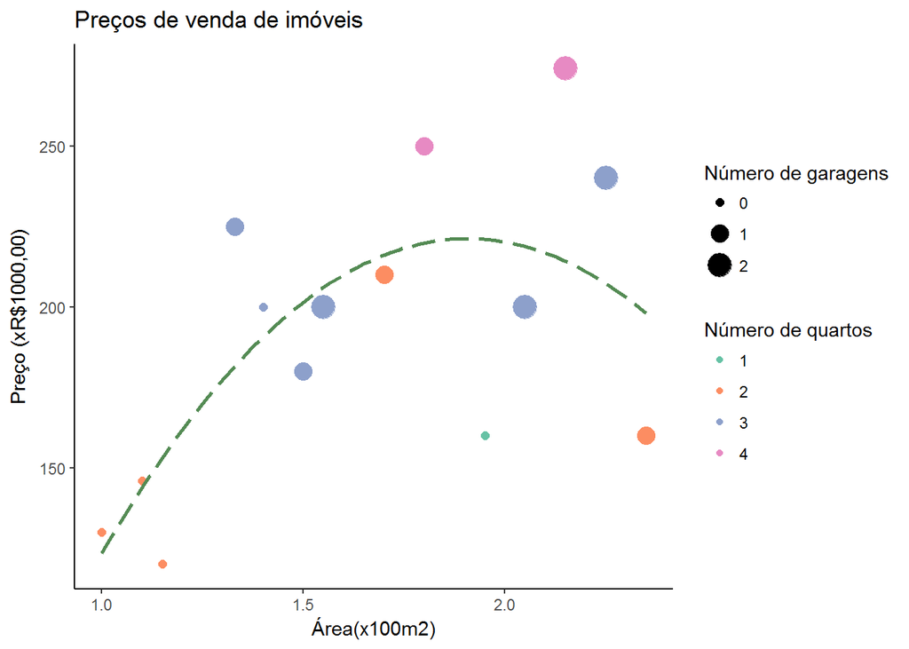

```
##
## Call:
## lm(formula = preco ~ poly(area, 2, raw = TRUE), data = housingSmall)
##
## Residuals:
##     Min      1Q  Median      3Q     Max
## -60.978 -20.802  -1.893  24.981  59.792
##
## Coefficients:
##                            Estimate Std. Error t value Pr(>|t|)
## (Intercept)                 -210.86     168.26  -1.253   0.2361
## poly(area, 2, raw = TRUE)1   453.01     210.14   2.156   0.0541 .
## poly(area, 2, raw = TRUE)2  -118.75      62.36  -1.904   0.0833 .
## ---
## Signif. codes:  0 '***' 0.001 '**' 0.01 '*' 0.05 '.' 0.1 ' ' 1
##
## Residual standard error: 36.58 on 11 degrees of freedom
## Multiple R-squared:  0.4615, Adjusted R-squared:  0.3636
## F-statistic: 4.714 on 2 and 11 DF,  p-value: 0.03322
```

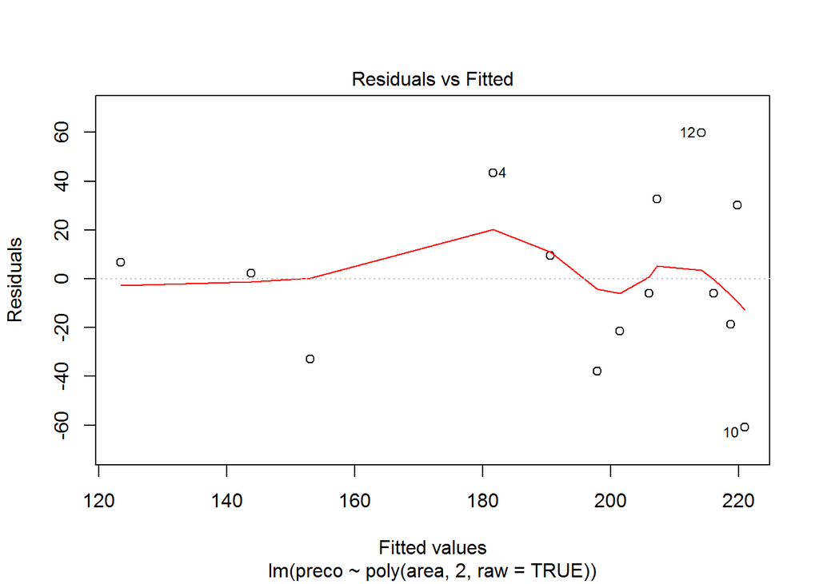

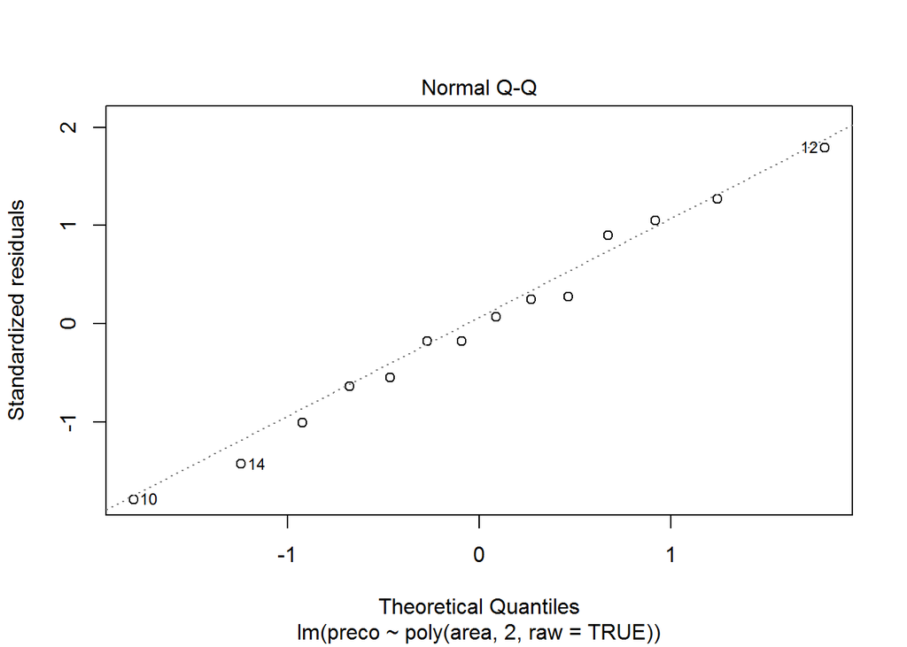

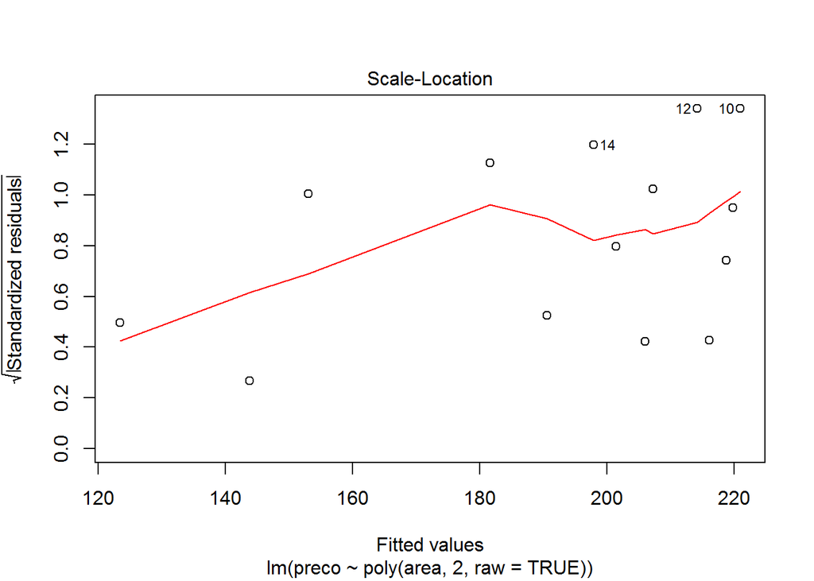

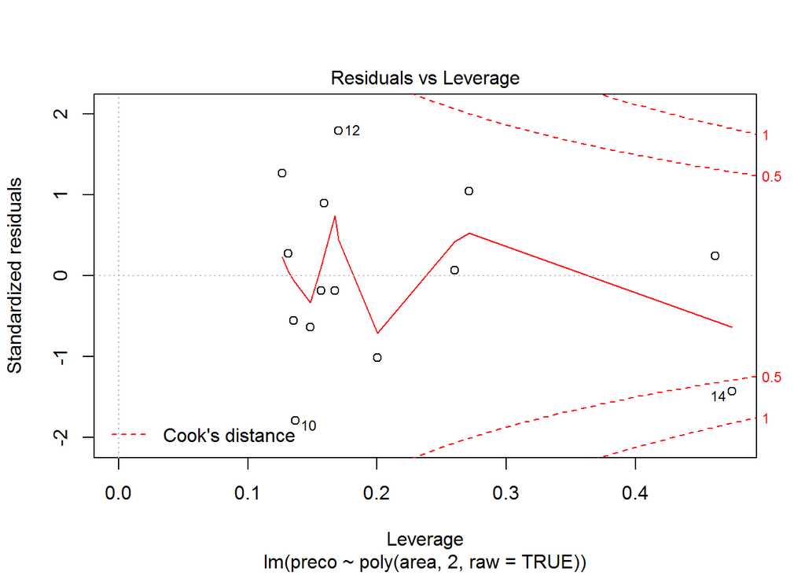

##### Preço ~ garagem

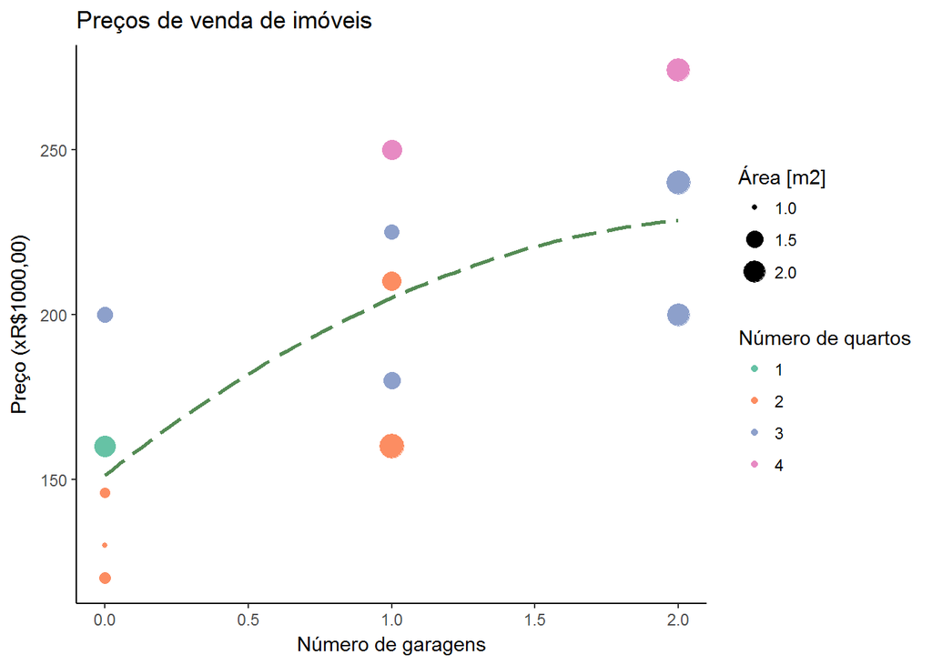

```
##
## Call:
## lm(formula = preco ~ poly(garagem, 2, raw = TRUE), data = housingSmall)
##
## Residuals:
##    Min     1Q Median     3Q    Max
## -45.00 -27.62  -0.10  17.88  48.80
##
## Coefficients:
##                               Estimate Std. Error t value Pr(>|t|)
## (Intercept)                     151.20      15.28   9.897 8.19e-07 ***
## poly(garagem, 2, raw = TRUE)1    68.95      39.13   1.762    0.106
## poly(garagem, 2, raw = TRUE)2   -15.15      19.10  -0.793    0.444
## ---
## Signif. codes:  0 '***' 0.001 '**' 0.01 '*' 0.05 '.' 0.1 ' ' 1
##
## Residual standard error: 34.16 on 11 degrees of freedom
## Multiple R-squared:  0.5303, Adjusted R-squared:  0.4449
## F-statistic:  6.21 on 2 and 11 DF,  p-value: 0.01566
```

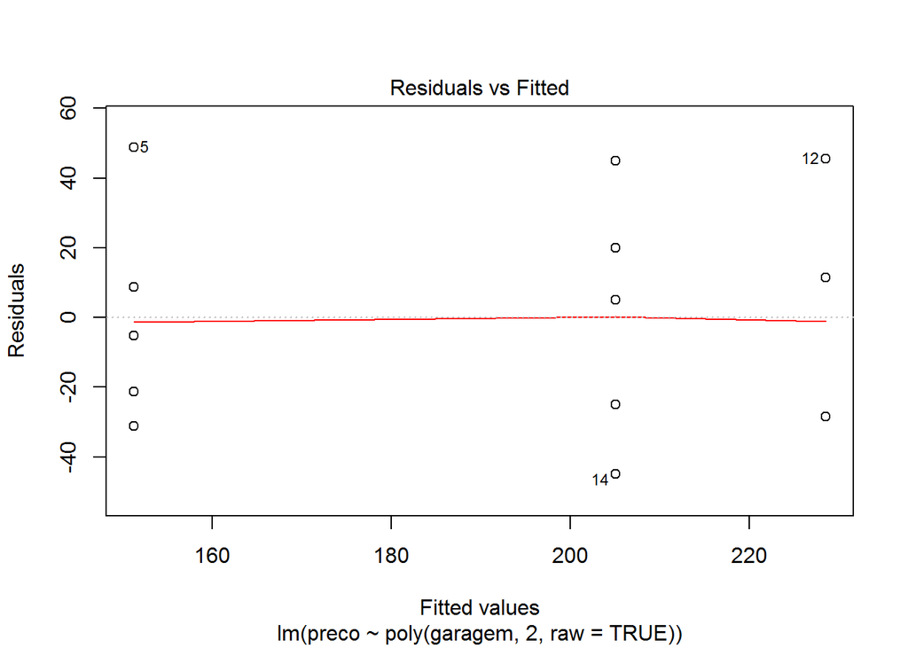

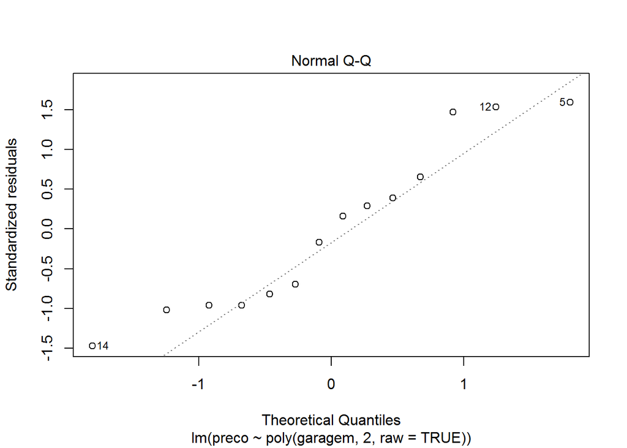

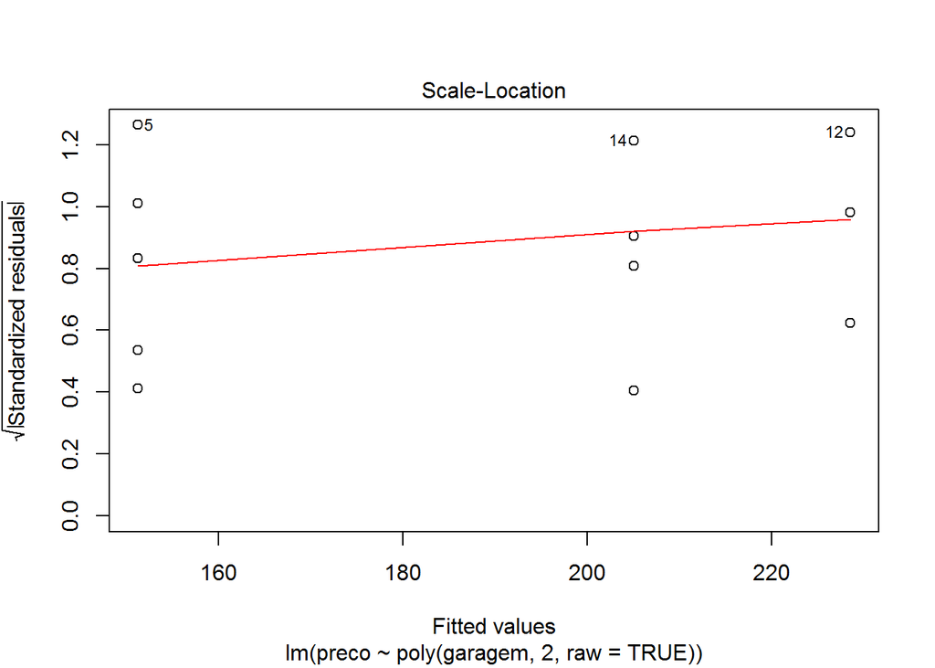

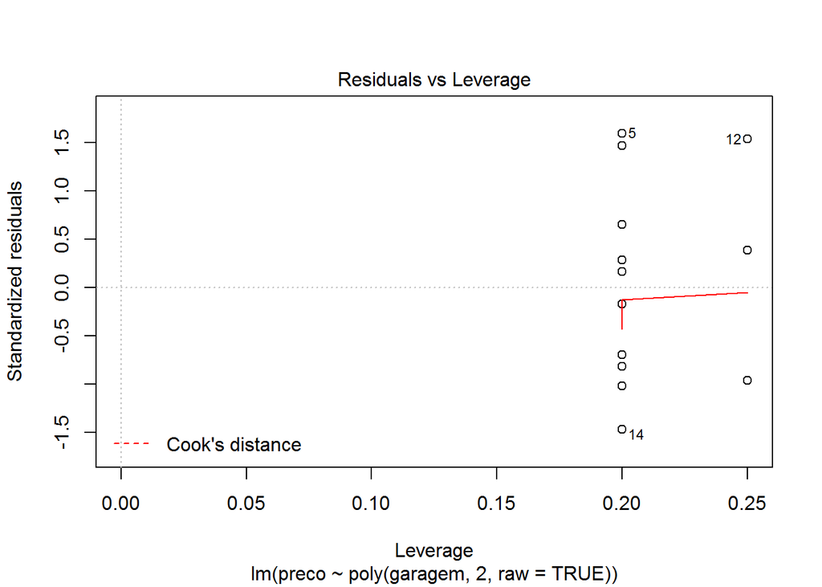

##### Preço ~ quartos

[figure not shown]

[output not shown]

[figure not shown]

[figure not shown]

[figure not shown]

[figure not shown]

Portanto, a seguir serão mostrados os modelos utilizando mais de uma variável.

#### Modelos de regressão múltipla - usando duas variáveis

##### Preço ~ area + garagens

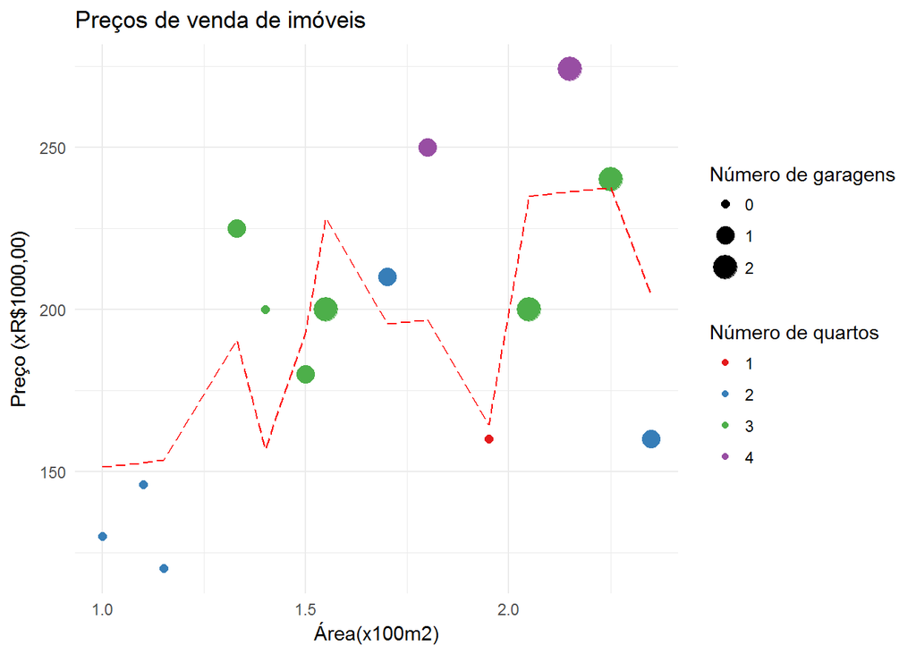

```
##
## Call:
## lm(formula = preco ~ area + garagem, data = housingSmall)
##
## Residuals:
##     Min      1Q  Median      3Q     Max
## -44.312 -26.364  -5.504  29.546  53.165
##
## Coefficients:
##             Estimate Std. Error t value Pr(>|t|)
## (Intercept)   137.77      40.80   3.377  0.00618 **
## area           13.59      28.44   0.478  0.64200
## garagem        34.59      15.18   2.278  0.04366 *
## ---
## Signif. codes:  0 '***' 0.001 '**' 0.01 '*' 0.05 '.' 0.1 ' ' 1
##
## Residual standard error: 34.76 on 11 degrees of freedom
## Multiple R-squared:  0.5136, Adjusted R-squared:  0.4251
## F-statistic: 5.807 on 2 and 11 DF,  p-value: 0.019
```

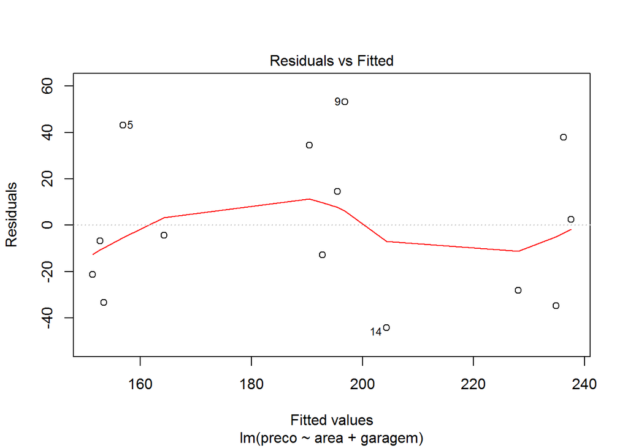

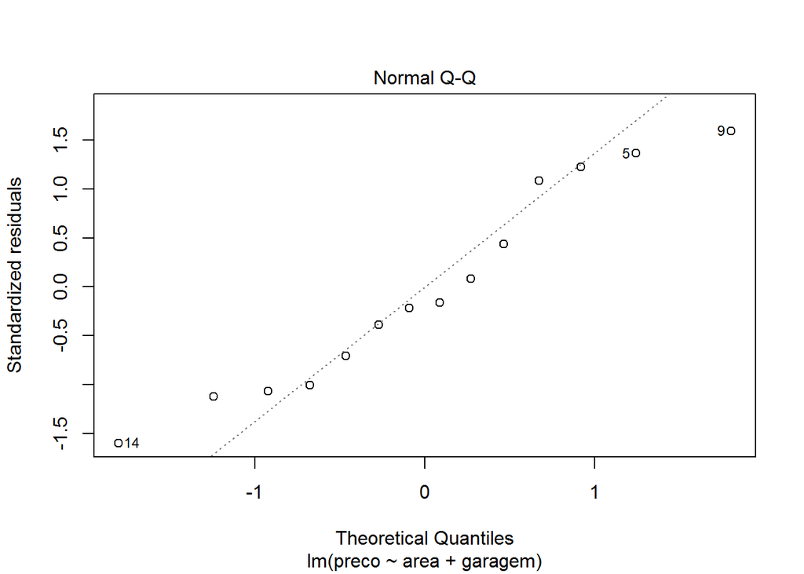

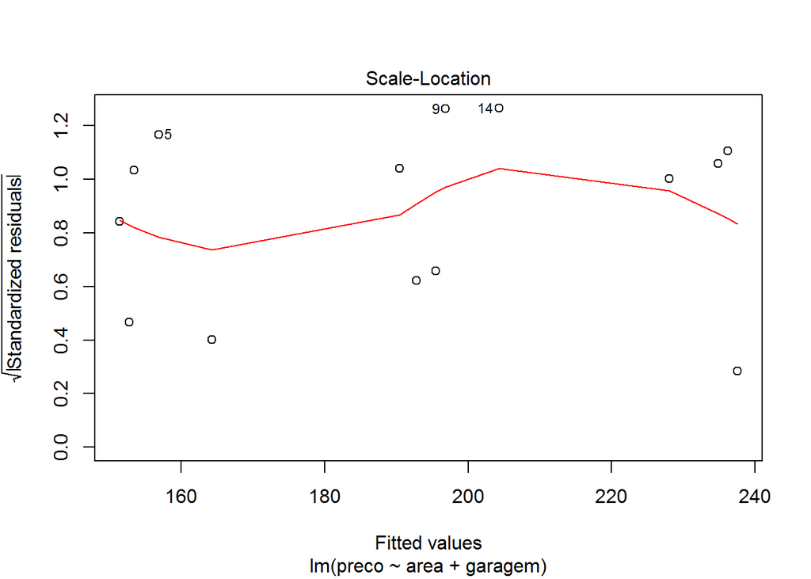

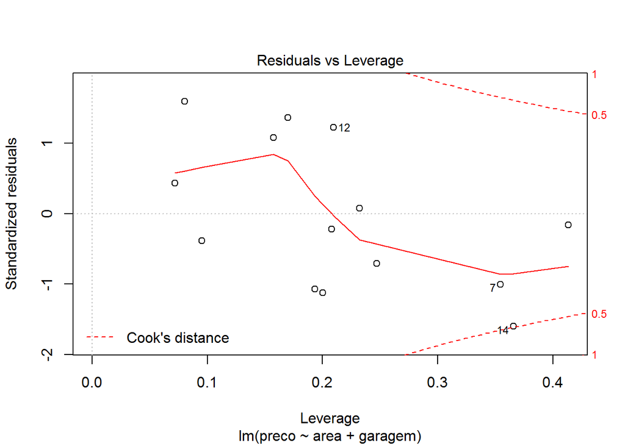

##### Preço ~ area + quartos

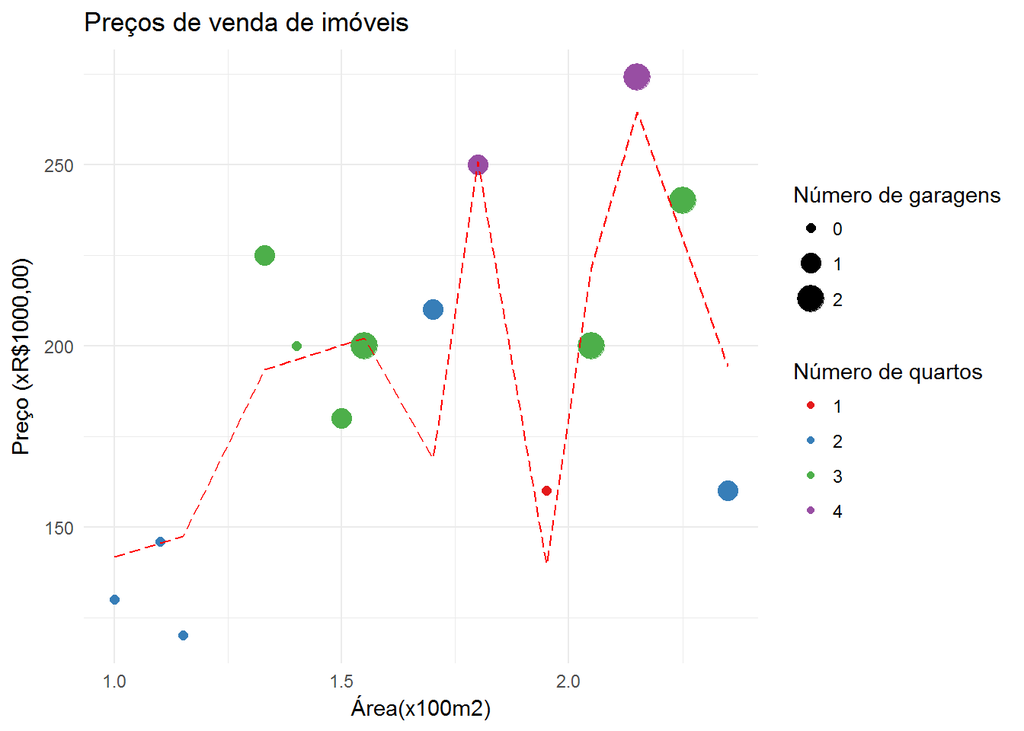

```
##
## Call:
## lm(formula = preco ~ area + quartos, data = housingSmall)
##
## Residuals:
##     Min      1Q  Median      3Q     Max
## -34.198 -17.969  -0.131  10.457  41.105
##
## Coefficients:
##             Estimate Std. Error t value Pr(>|t|)
## (Intercept)    24.78      30.06   0.824 0.427321
## area           38.93      15.32   2.541 0.027408 *
## quartos        38.97       8.05   4.841 0.000518 ***
## ---
## Signif. codes:  0 '***' 0.001 '**' 0.01 '*' 0.05 '.' 0.1 ' ' 1
##
## Residual standard error: 23.84 on 11 degrees of freedom
## Multiple R-squared:  0.7713, Adjusted R-squared:  0.7297
## F-statistic: 18.55 on 2 and 11 DF,  p-value: 0.0002994
```

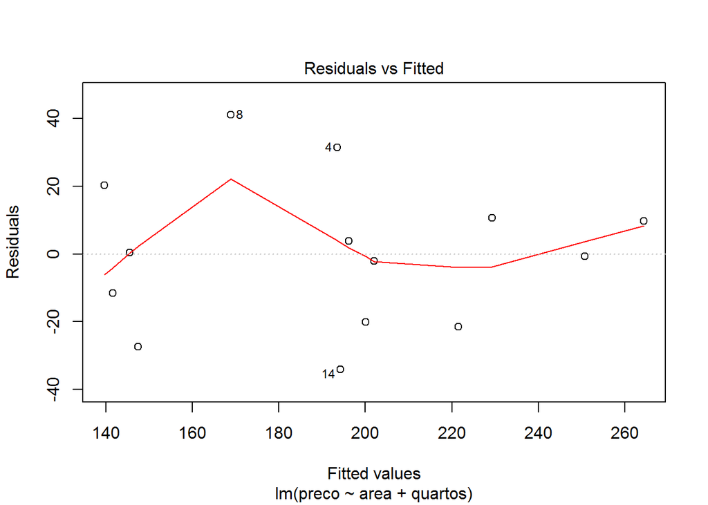

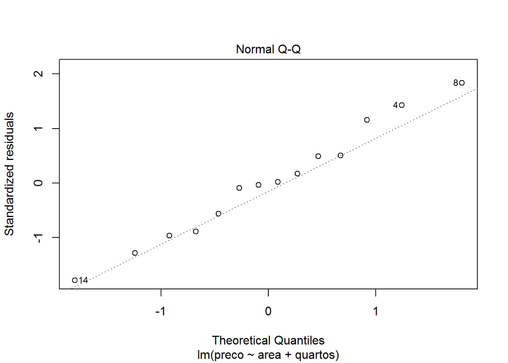

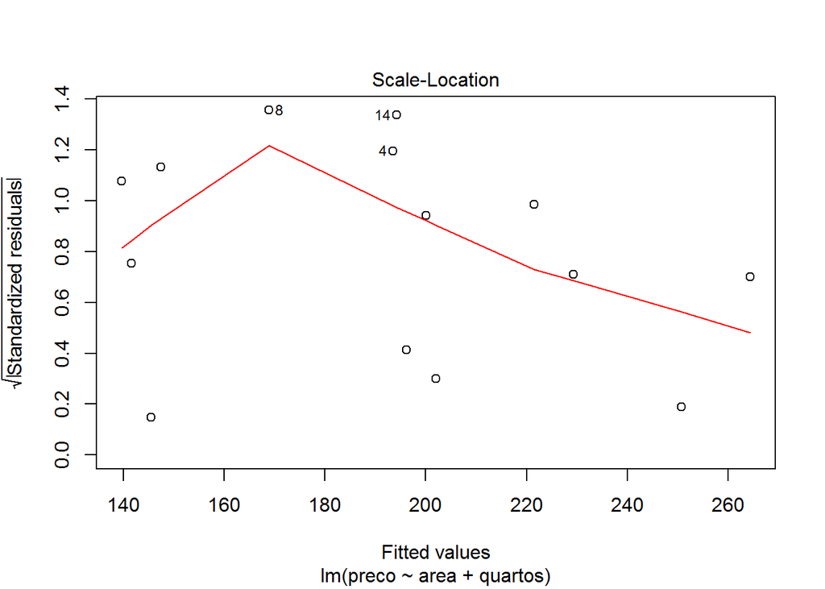

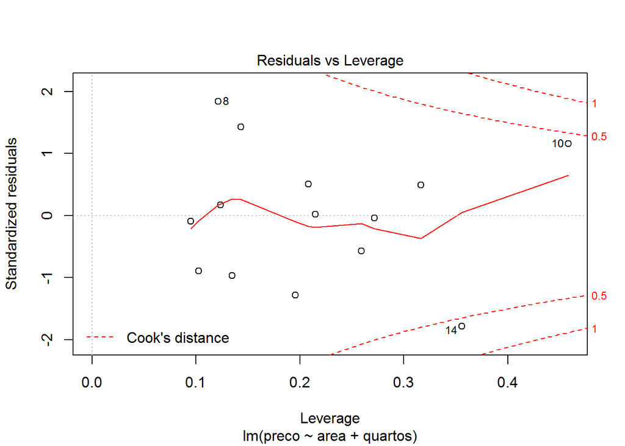

##### Preço ~ garagem + quartos

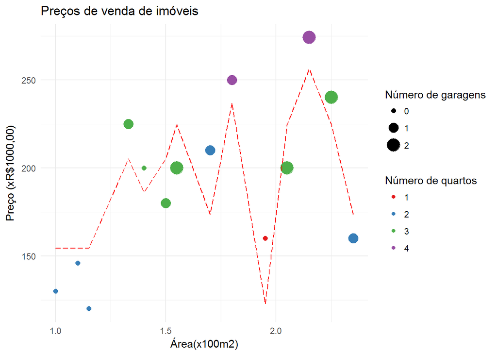

```
##
## Call:
## lm(formula = preco ~ garagem + quartos, data = housingSmall)
##
## Residuals:
##     Min      1Q  Median      3Q     Max
## -34.273 -24.383   2.423  17.313  37.416
##
## Coefficients:
##             Estimate Std. Error t value Pr(>|t|)
## (Intercept)    90.89      25.65   3.543  0.00461 **
## garagem        19.23      11.45   1.679  0.12136
## quartos        31.69      11.28   2.811  0.01695 *
## ---
## Signif. codes:  0 '***' 0.001 '**' 0.01 '*' 0.05 '.' 0.1 ' ' 1
##
## Residual standard error: 26.8 on 11 degrees of freedom
## Multiple R-squared:  0.711,  Adjusted R-squared:  0.6585
## F-statistic: 13.53 on 2 and 11 DF,  p-value: 0.001084
```

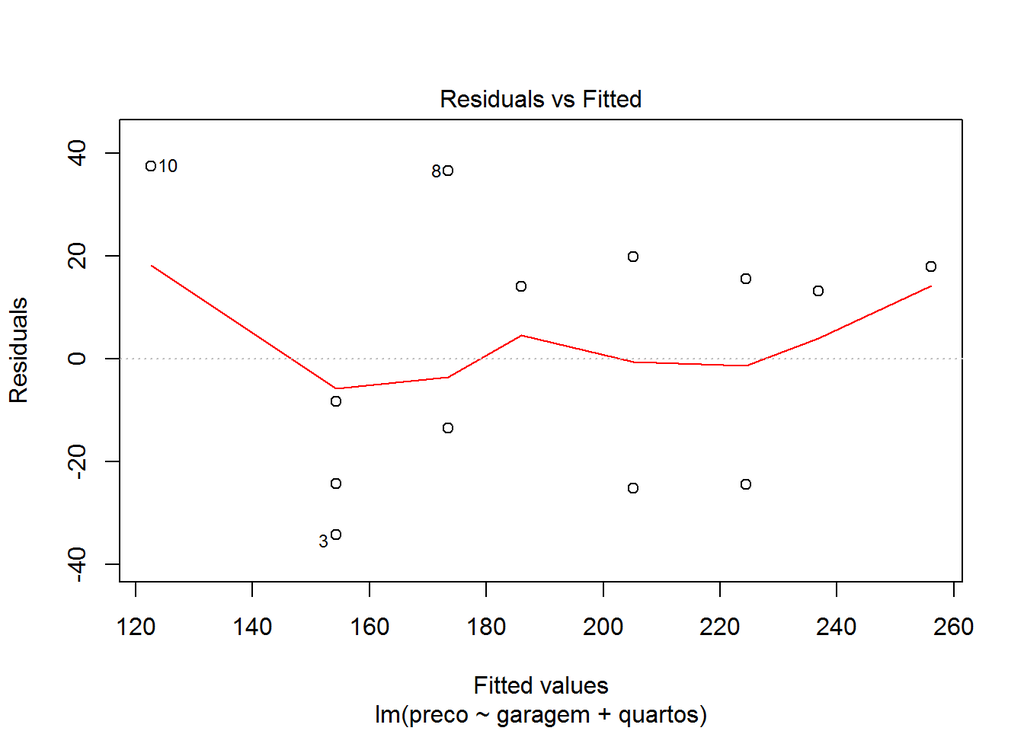

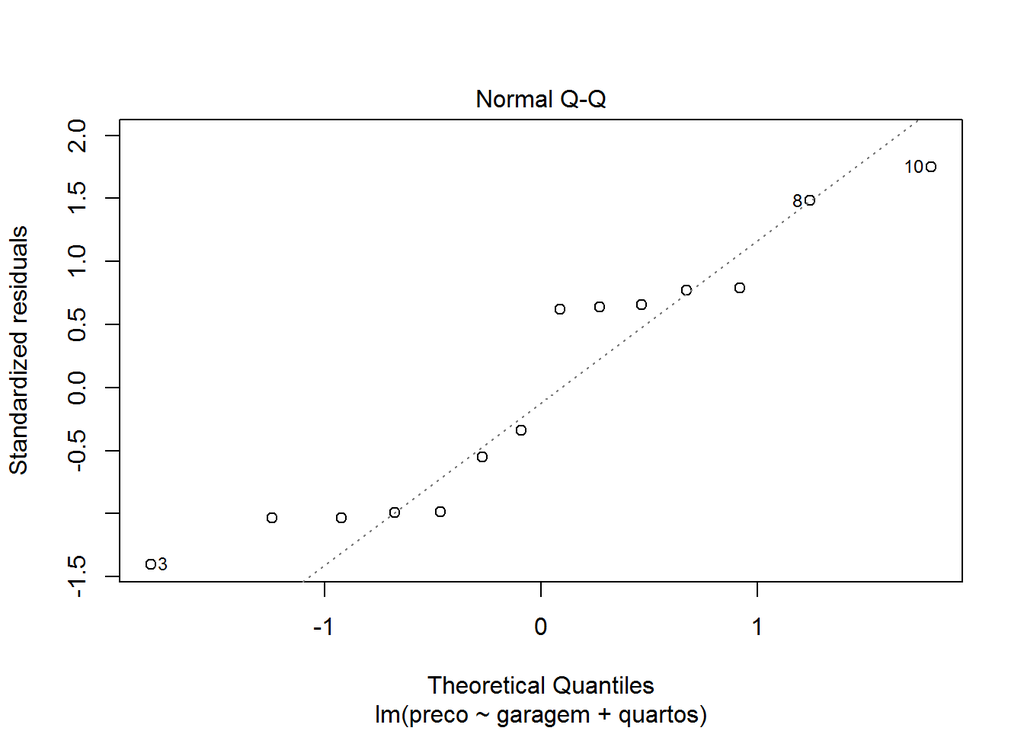

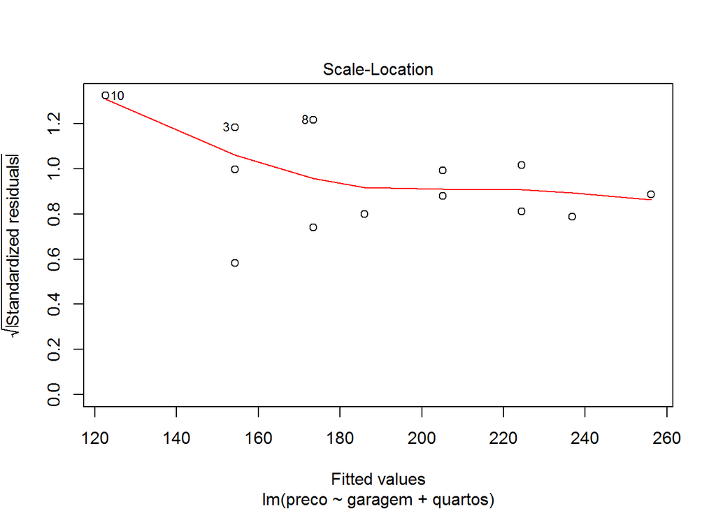

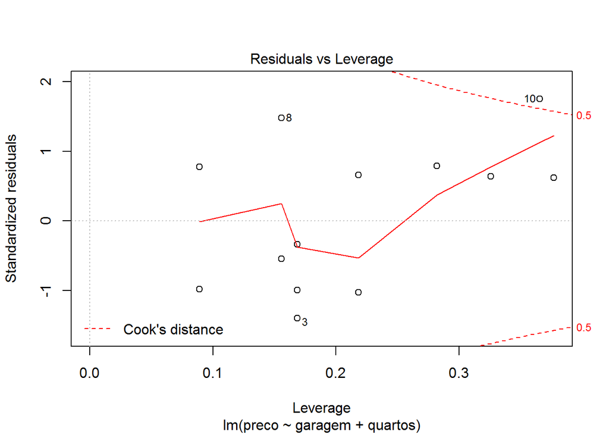

Apesar de valores de R<sup>2</sup> relativamente altos, os resíduos não tiveram o comportamento adequado. Sendo assim, os modelos utilizando duas variáveis também não tiveram bom desempenho. Ainda, os três resultados aparentam estar sobreajustados.

Partindo do comportamento não-linear dos resíduos, propõe-se a seguir um modelo de regressão polinomial múltipla utilizando duas variáveis.

#### Modelos de regressão múltipla - usando duas variáveis

##### Preco ~ Polym(area, garagem, 3)

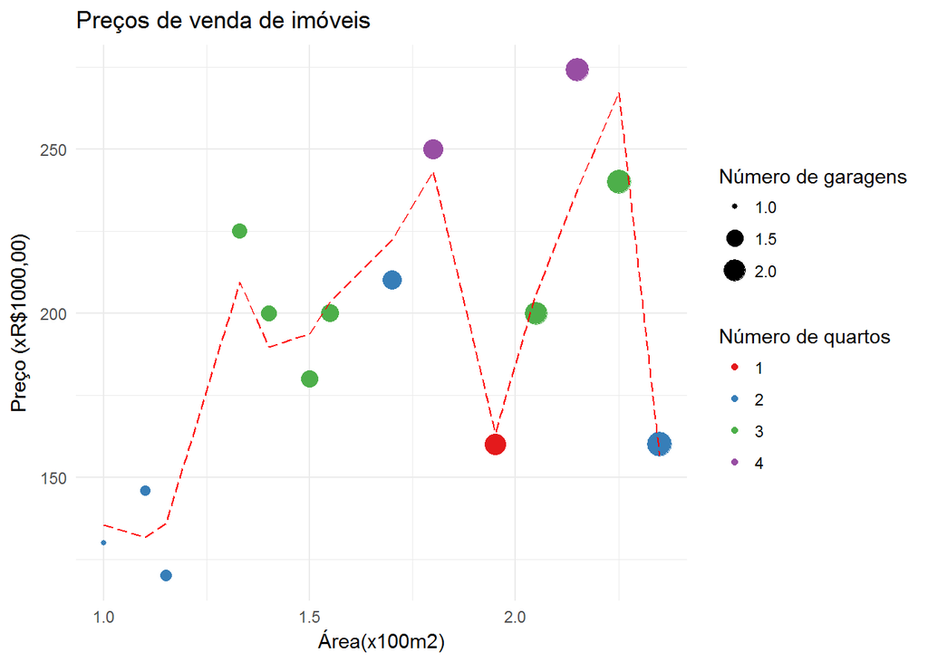

```
##
## Call:
## lm(formula = preco ~ polym(area, garagem, degree = 3, raw = TRUE),
##     data = housingSmall)
##
## Residuals:
##       1       2       3       4       5       6       7       8       9
##  -5.526  14.322 -15.798  15.688  10.389 -13.707  -3.551 -12.475   6.833
##      10      11      12      13      14
##  -3.388  -5.785  36.430 -27.093   3.661
##
## Coefficients: (1 not defined because of singularities)
##                                                 Estimate Std. Error
## (Intercept)                                       2208.6     1252.1
## polym(area, garagem, degree = 3, raw = TRUE)1.0  -4921.1     2678.1
## polym(area, garagem, degree = 3, raw = TRUE)2.0   3755.7     1864.0
## polym(area, garagem, degree = 3, raw = TRUE)3.0   -907.6      421.4
## polym(area, garagem, degree = 3, raw = TRUE)0.1   2019.0      827.9
## polym(area, garagem, degree = 3, raw = TRUE)1.1  -2868.7     1202.2
## polym(area, garagem, degree = 3, raw = TRUE)2.1    992.7      418.4
## polym(area, garagem, degree = 3, raw = TRUE)0.2    452.6      255.6
## polym(area, garagem, degree = 3, raw = TRUE)1.2   -281.6      150.6
## polym(area, garagem, degree = 3, raw = TRUE)0.3       NA         NA
##                                                 t value Pr(>|t|)
## (Intercept)                                       1.764   0.1380
## polym(area, garagem, degree = 3, raw = TRUE)1.0  -1.838   0.1255
## polym(area, garagem, degree = 3, raw = TRUE)2.0   2.015   0.1000
## polym(area, garagem, degree = 3, raw = TRUE)3.0  -2.154   0.0838 .
## polym(area, garagem, degree = 3, raw = TRUE)0.1   2.439   0.0588 .
## polym(area, garagem, degree = 3, raw = TRUE)1.1  -2.386   0.0627 .
## polym(area, garagem, degree = 3, raw = TRUE)2.1   2.373   0.0637 .
## polym(area, garagem, degree = 3, raw = TRUE)0.2   1.771   0.1369
## polym(area, garagem, degree = 3, raw = TRUE)1.2  -1.869   0.1205
## polym(area, garagem, degree = 3, raw = TRUE)0.3      NA       NA
## ---
## Signif. codes:  0 '***' 0.001 '**' 0.01 '*' 0.05 '.' 0.1 ' ' 1
##
## Residual standard error: 25.93 on 5 degrees of freedom
## Multiple R-squared:  0.877,  Adjusted R-squared:  0.6802
## F-statistic: 4.456 on 8 and 5 DF,  p-value: 0.05828
```

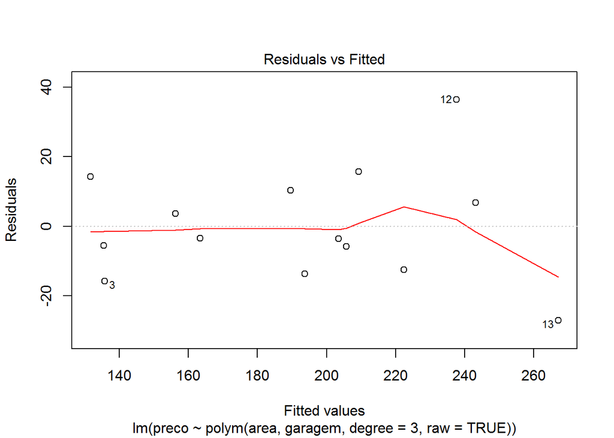

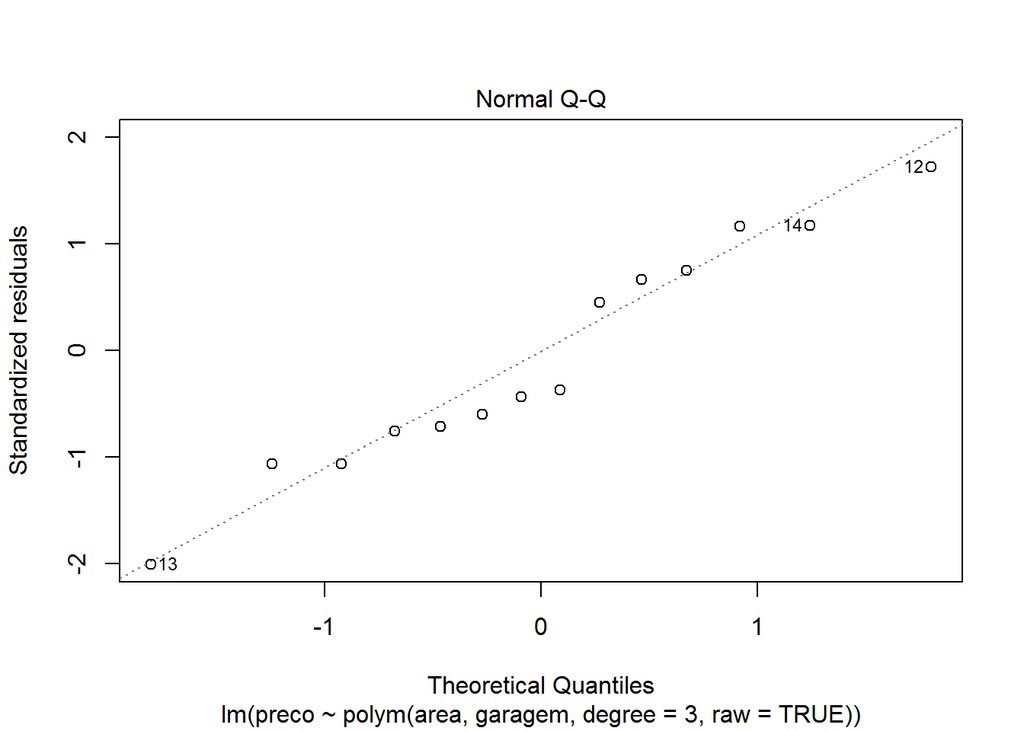

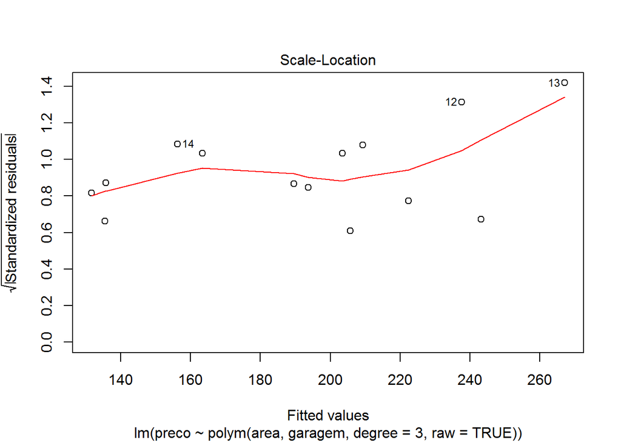

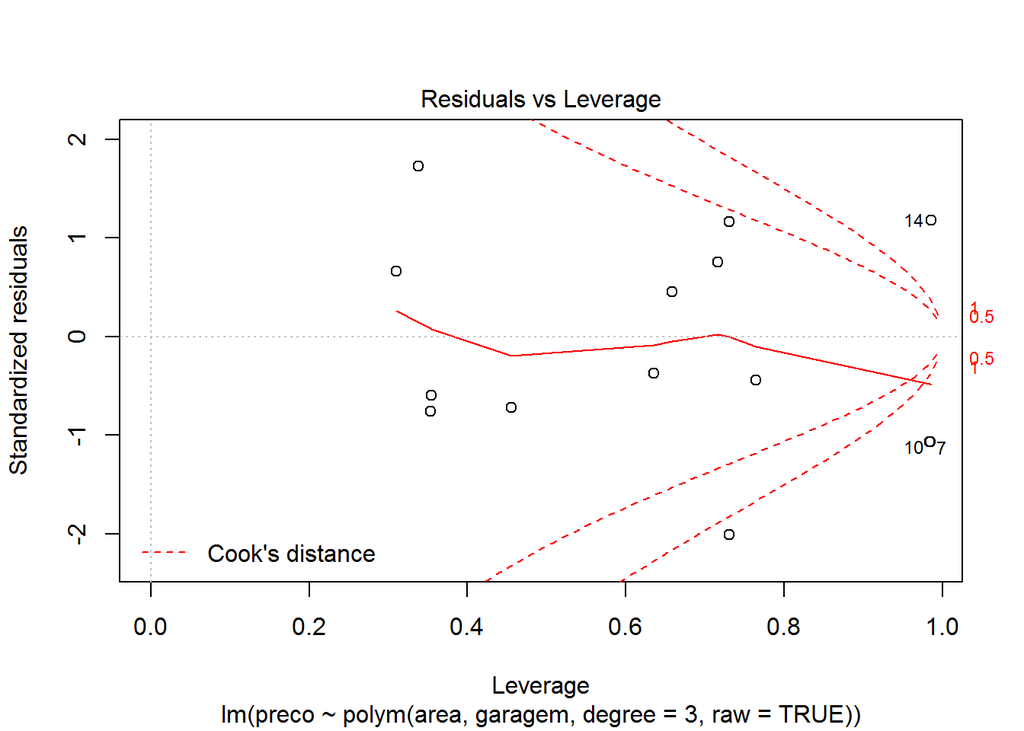

##### Preco ~ Polym(area, quartos, 3)

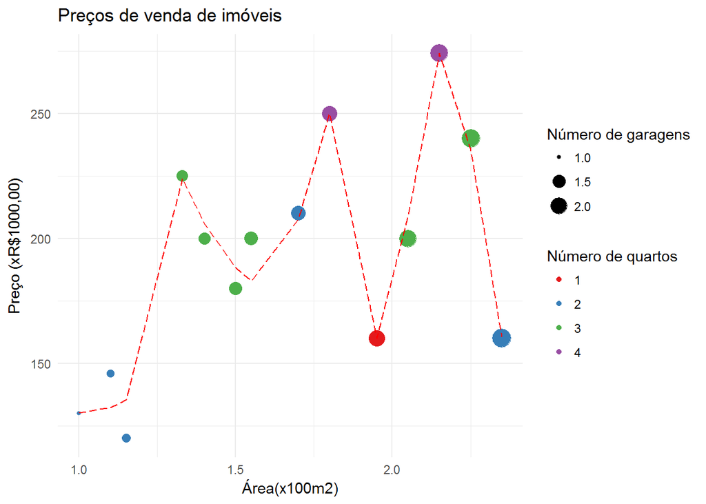

```
##
## Call:
## lm(formula = preco ~ polym(area, quartos, degree = 3, raw = TRUE),
##     data = housingSmall)
##
## Residuals:
##          1          2          3          4          5          6
## -9.682e-02  1.371e+01 -1.544e+01  1.087e+00 -5.862e+00 -8.379e+00
##          7          8          9         10         11         12
##  1.707e+01  2.342e+00 -2.727e-14  4.045e-14 -8.417e+00 -7.511e-15
##         13         14
##  4.499e+00 -5.142e-01
##
## Coefficients:
##                                                 Estimate Std. Error
## (Intercept)                                     -1518.57     617.78
## polym(area, quartos, degree = 3, raw = TRUE)1.0  1292.77    1057.68
## polym(area, quartos, degree = 3, raw = TRUE)2.0   134.84     739.29
## polym(area, quartos, degree = 3, raw = TRUE)3.0  -227.10     156.72
## polym(area, quartos, degree = 3, raw = TRUE)0.1  1072.41     589.74
## polym(area, quartos, degree = 3, raw = TRUE)1.1 -1138.71     349.07
## polym(area, quartos, degree = 3, raw = TRUE)2.1   438.11     112.85
## polym(area, quartos, degree = 3, raw = TRUE)0.2   -39.50     123.74
## polym(area, quartos, degree = 3, raw = TRUE)1.2   -91.23      52.05
## polym(area, quartos, degree = 3, raw = TRUE)0.3    28.43      11.08
##                                                 t value Pr(>|t|)
## (Intercept)                                      -2.458   0.0698 .
## polym(area, quartos, degree = 3, raw = TRUE)1.0   1.222   0.2887
## polym(area, quartos, degree = 3, raw = TRUE)2.0   0.182   0.8641
## polym(area, quartos, degree = 3, raw = TRUE)3.0  -1.449   0.2209
## polym(area, quartos, degree = 3, raw = TRUE)0.1   1.818   0.1431
## polym(area, quartos, degree = 3, raw = TRUE)1.1  -3.262   0.0310 *
## polym(area, quartos, degree = 3, raw = TRUE)2.1   3.882   0.0178 *
## polym(area, quartos, degree = 3, raw = TRUE)0.2  -0.319   0.7655
## polym(area, quartos, degree = 3, raw = TRUE)1.2  -1.753   0.1545
## polym(area, quartos, degree = 3, raw = TRUE)0.3   2.565   0.0623 .
## ---
## Signif. codes:  0 '***' 0.001 '**' 0.01 '*' 0.05 '.' 0.1 ' ' 1
##
## Residual standard error: 15.17 on 4 degrees of freedom
## Multiple R-squared:  0.9663, Adjusted R-squared:  0.8906
## F-statistic: 12.75 on 9 and 4 DF,  p-value: 0.01296
```

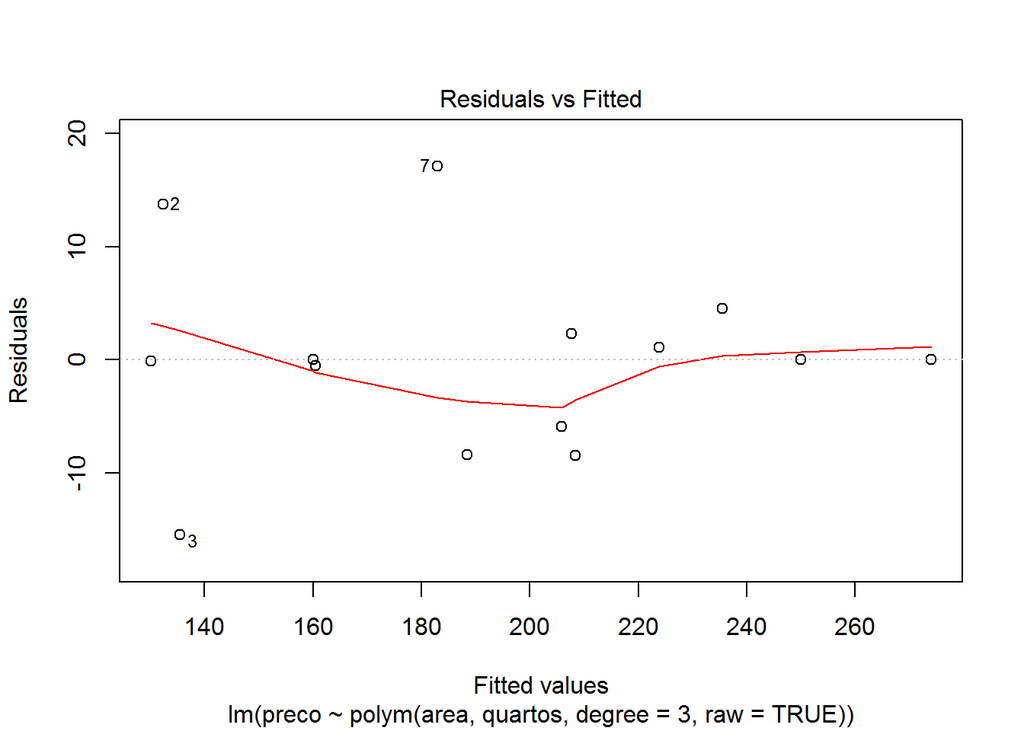

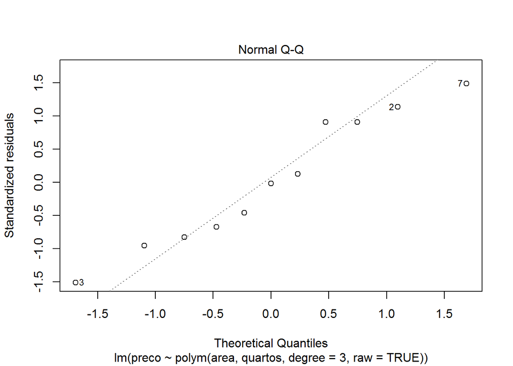

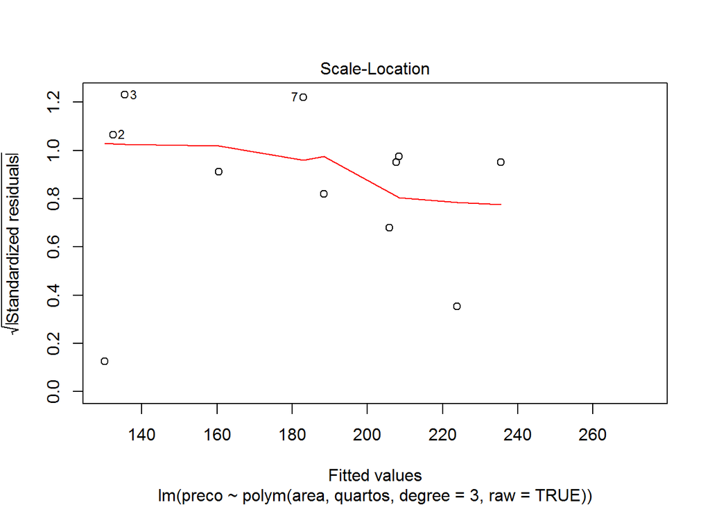

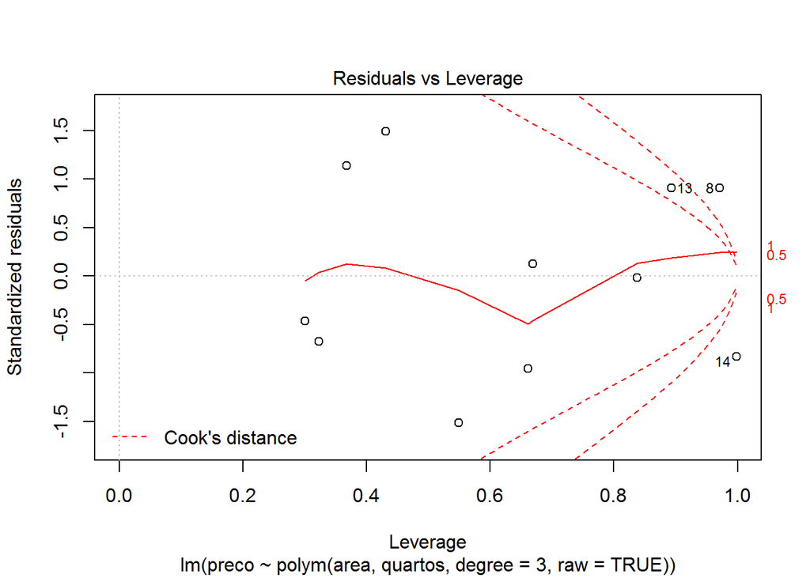

##### Preco ~ Polym(garagem, quartos, 3)

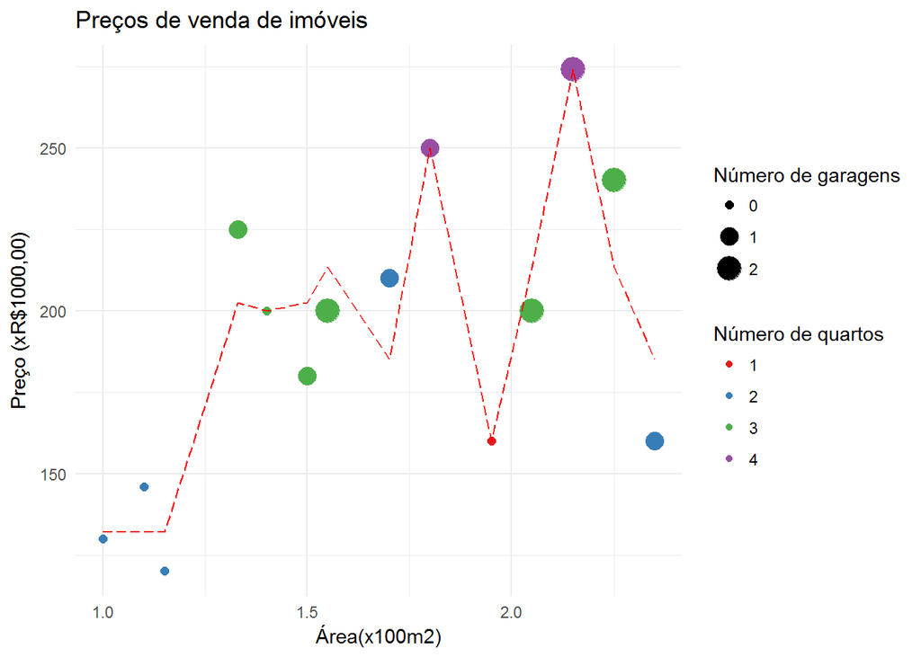

```
##
## Call:
## lm(formula = preco ~ polym(garagem, quartos, degree = 3, raw = TRUE),
##     data = housingSmall)
##
## Residuals:
##    Min     1Q Median     3Q    Max
## -25.00 -13.00   0.00  10.50  26.67
##
## Coefficients: (2 not defined because of singularities)
##                                                    Estimate Std. Error
## (Intercept)                                          284.00      89.21
## polym(garagem, quartos, degree = 3, raw = TRUE)1.0   146.33     146.03
## polym(garagem, quartos, degree = 3, raw = TRUE)2.0  -190.33     148.11
## polym(garagem, quartos, degree = 3, raw = TRUE)3.0       NA         NA
## polym(garagem, quartos, degree = 3, raw = TRUE)0.1  -172.00      92.03
## polym(garagem, quartos, degree = 3, raw = TRUE)1.1    49.67     129.85
## polym(garagem, quartos, degree = 3, raw = TRUE)2.1    64.83      48.44
## polym(garagem, quartos, degree = 3, raw = TRUE)0.2    48.00      22.59
## polym(garagem, quartos, degree = 3, raw = TRUE)1.2   -33.00      32.34
## polym(garagem, quartos, degree = 3, raw = TRUE)0.3       NA         NA
##                                                    t value Pr(>|t|)
## (Intercept)                                          3.183   0.0190 *
## polym(garagem, quartos, degree = 3, raw = TRUE)1.0   1.002   0.3550
## polym(garagem, quartos, degree = 3, raw = TRUE)2.0  -1.285   0.2461
## polym(garagem, quartos, degree = 3, raw = TRUE)3.0      NA       NA
## polym(garagem, quartos, degree = 3, raw = TRUE)0.1  -1.869   0.1108
## polym(garagem, quartos, degree = 3, raw = TRUE)1.1   0.382   0.7153
## polym(garagem, quartos, degree = 3, raw = TRUE)2.1   1.338   0.2293
## polym(garagem, quartos, degree = 3, raw = TRUE)0.2   2.125   0.0777 .
## polym(garagem, quartos, degree = 3, raw = TRUE)1.2  -1.020   0.3469
## polym(garagem, quartos, degree = 3, raw = TRUE)0.3      NA       NA
## ---
## Signif. codes:  0 '***' 0.001 '**' 0.01 '*' 0.05 '.' 0.1 ' ' 1
##
## Residual standard error: 24.74 on 6 degrees of freedom
## Multiple R-squared:  0.8656, Adjusted R-squared:  0.7088
## F-statistic:  5.52 on 7 and 6 DF,  p-value: 0.02692
```

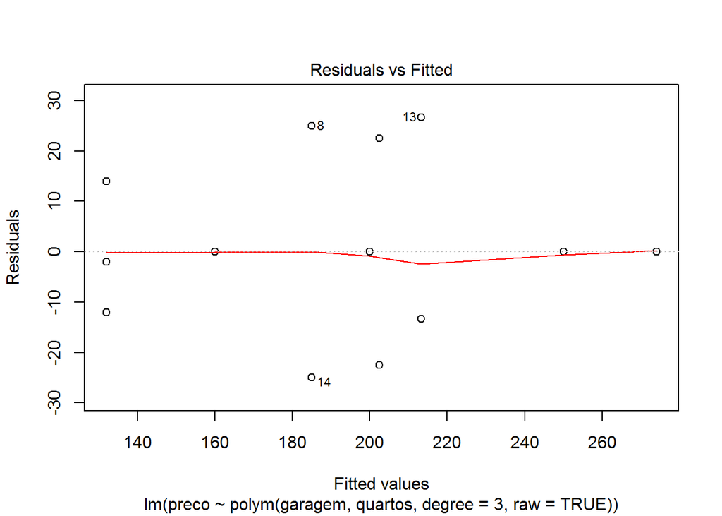

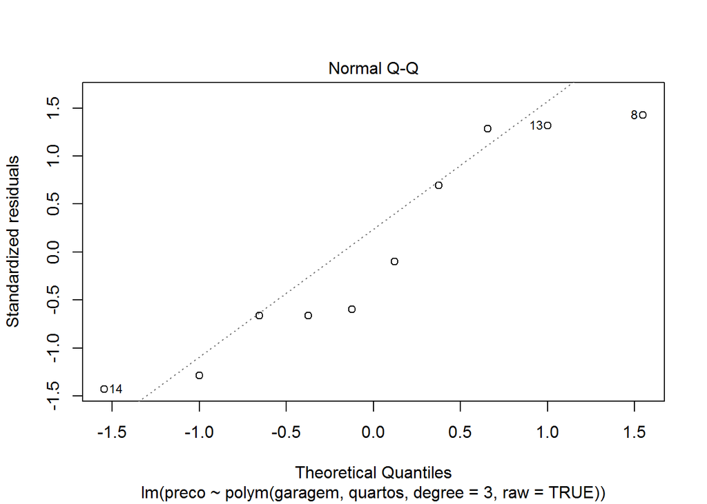

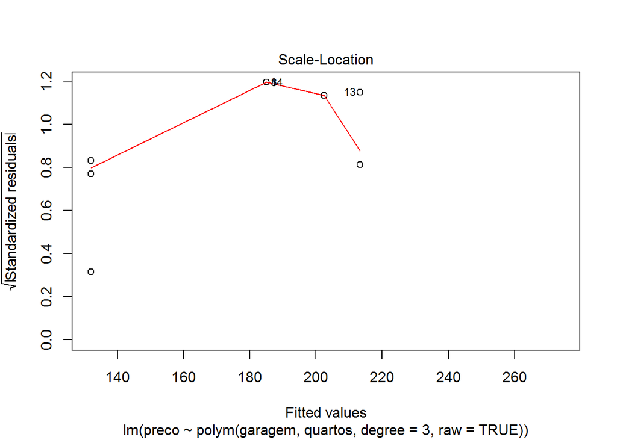

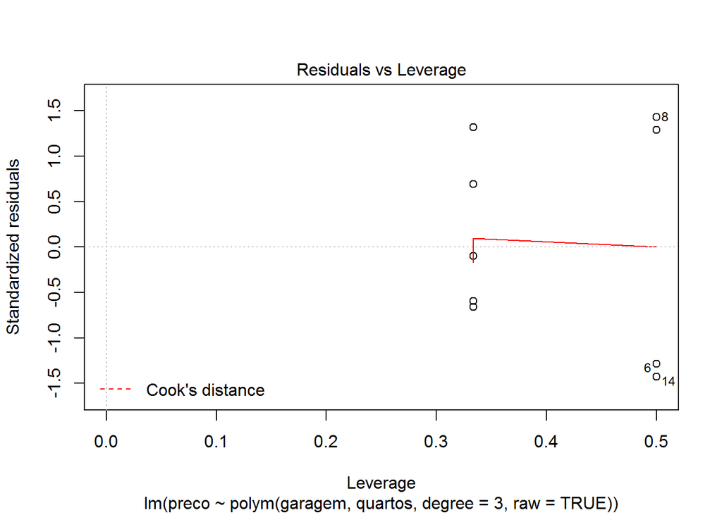

Os modelos propostos não resolveram o efeito nos resíduos. Assim como o anterior, também aparentam ser modelos sobreajustados.

A seguir, todas as variáveis foram utilizadas para desenvolver o modelo.